# om() - ADAM-based occurrence model

Ivan Svetunkov

2026-09-04

The `om()` function is the ADAM-based occurrence model for intermittent demand data. It estimates the probability of demand occurrence $p_t$ using the full ADAM state-space framework, which means the underlying model for the occurrence dynamics can be an ETS model, an ARIMA model, a regression model, or a combination of all three.

The five link functions (occurrence types) supported by `om()` are identical to those in `oes()`: **fixed**, **odds-ratio**, **inverse-odds-ratio**, **direct**, and **general**. For the mathematical derivations behind each link function see the oes vignette. This vignette focuses on the added flexibility that `om()` inherits from ADAM.

## The data

We use the same artificial data as in the oes vignette:

```r
set.seed(41)
y <- ts(c(rpois(20, 0.25), rpois(20, 0.5), rpois(20, 1),
          rpois(20, 2),    rpois(20, 3),    rpois(20, 5)))
```

The series starts sparse (low Poisson rate) and becomes increasingly dense. Any non-zero value in the input is automatically binarised to 1 by `om()`, so passing a count series is fine.

## om(): ETS occurrence model

The simplest call resembles `oes()`. We fix an ETS(M,N,N) model and use the odds-ratio link:

```r
omETS <- om(y, model="MNN", occurrence="odds-ratio", h=10, holdout=TRUE)
omETS
```

```
## Occurrence model
## Time elapsed: 0.01 seconds
## Model estimated using om() function: oETS(MNN)[O]
## With backcasting initialisation
## Distribution assumed in the model: Cumulative Logistic
## Loss function type: likelihood; Loss function value: 61.5463
## Persistence vector g:
##  alpha
## 0.5605
##
## Sample size: 110
## Number of estimated parameters: 2
## Number of degrees of freedom: 108
## Information criteria:
##      AIC     AICc      BIC     BICc
## 127.0925 127.2047 132.4935 132.7570
##
## Forecast errors:
## Asymmetry: 100%; sMSE: 0.072%; rRMSE: Inf; sPIS: -147.893%; sCE: 26.89%
```

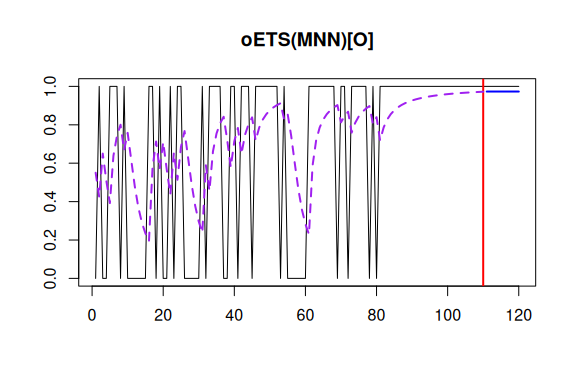

```r
plot(omETS, 7)
```

Model selection across ETS components is supported through the same `"Z"` / `"X"` / `"Y"` wildcards used in `adam()` and `es()`. The default `model="ZXZ"` searches across all sensible error types and seasonal patterns:

```r
omETSAuto <- om(y, occurrence="odds-ratio", h=10, holdout=TRUE)
omETSAuto
```

```
## Occurrence model
## Time elapsed: 0.03 seconds
## Model estimated using om() function: oETS(ANN)[O]
## With backcasting initialisation
## Distribution assumed in the model: Cumulative Logistic
## Loss function type: likelihood; Loss function value: 60.3197
## Persistence vector g:
##  alpha
## 0.3257
##
## Sample size: 110
## Number of estimated parameters: 2
## Number of degrees of freedom: 108
## Information criteria:
##      AIC     AICc      BIC     BICc
## 124.6394 124.7515 130.0403 130.3039
##
## Forecast errors:
## Asymmetry: 100%; sMSE: 0.244%; rRMSE: Inf; sPIS: -271.726%; sCE: 49.405%
```

The fitted occurrence model can be passed directly to `adam()` for a full iETS model that jointly describes demand occurrence and demand sizes:

```r
adam(y, "MNN", occurrence=omETS, h=10, holdout=TRUE, silent=FALSE)
```

```
## Time elapsed: 0.01 seconds
## Model estimated using adam() function: iETS(MNN)[O]
## With backcasting initialisation
## Occurrence model type: Odds ratio
## Distribution assumed in the model: Mixture of Bernoulli and Gamma
## Loss function type: likelihood; Loss function value: 145.5116
## Persistence vector g:
##  alpha
## 0.1784
##
## Sample size: 110
## Number of estimated parameters: 3
## Number of degrees of freedom: 107
## Number of provided parameters: 2
## Information criteria:
##      AIC     AICc      BIC     BICc
## 420.1158 420.3422 428.2172 428.7494
##
## Forecast errors:
## Asymmetry: 17.581%; sMSE: 47.116%; rRMSE: 0.907; sPIS: 1204.445%; sCE: -8.642%
```

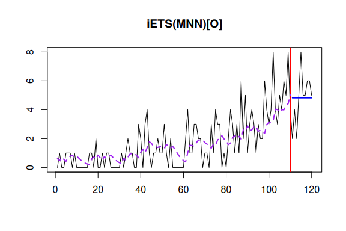

## om(): ARIMA occurrence model

Any ADAM-supported ARIMA structure can drive the occurrence dynamics. Set `model="NNN"` to suppress ETS components and specify the ARIMA orders directly. Note that automatic ARIMA order selection requires using `auto.om()` (see below) or passing `orders=list(ar=..., i=..., ma=..., select=TRUE)`:

```r
omARIMA <- om(y, model="NNN",
              orders=list(ar=1, i=0, ma=1),
              occurrence="odds-ratio", h=10, holdout=TRUE)
omARIMA
```

```
## Occurrence model
## Time elapsed: 0.02 seconds
## Model estimated using om() function: oARIMA(1,0,1)[O]
## With backcasting initialisation
## Distribution assumed in the model: Cumulative Logistic
## Loss function type: likelihood; Loss function value: 60.32
## ARMA parameters of the model:
##       Lag 1
## AR(1)     1
##         Lag 1
## MA(1) -0.6735
##
## Sample size: 110
## Number of estimated parameters: 3
## Number of degrees of freedom: 107
## Information criteria:
##      AIC     AICc      BIC     BICc
## 126.6400 126.8664 134.7415 135.2736
##
## Forecast errors:
## Asymmetry: 100%; sMSE: 0.243%; rRMSE: Inf; sPIS: -271.342%; sCE: 49.338%
```

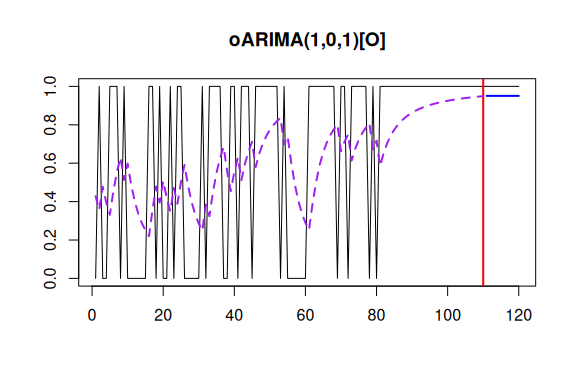

```r
plot(omARIMA, 7)
```

## om(): Regression occurrence model

External regressors are incorporated via `cbind()`, exactly as in `adam()`. The first column of the matrix is treated as the response; subsequent columns become regressors. Here we use the `Seatbelts` dataset from the `datasets` package: the response is a binary indicator for above-median driver casualties, and the predictor is the seatbelt law indicator:

```r
data(Seatbelts)
highDeaths <- as.integer(Seatbelts[, "DriversKilled"] > median(Seatbelts[, "DriversKilled"]))
ySeat <- ts(cbind(highDeaths, law=Seatbelts[, "law"]), start=c(1969, 1), frequency=12)
omReg <- om(ySeat, model="NNN",
            occurrence="odds-ratio", regressors="use",
            h=12, holdout=TRUE)
omReg
```

```
## Occurrence model
## Time elapsed: 0 seconds
## Model estimated using om() function: Regression
## With optimal initialisation
## Distribution assumed in the model: Cumulative Logistic
## Loss function type: likelihood; Loss function value: 122.0001
## Sample size: 180
## Number of estimated parameters: 2
## Number of degrees of freedom: 178
## Information criteria:
##      AIC     AICc      BIC     BICc
## 248.0002 248.0680 254.3861 254.5621
##
## Forecast errors:
## Asymmetry: 3.655%; sMSE: 24.505%; rRMSE: 0.857; sPIS: 421.551%; sCE: 181.3%
```

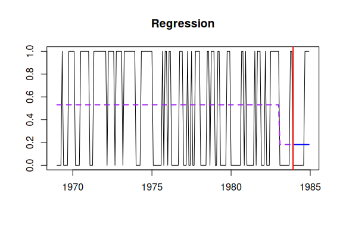

```r
plot(omReg, 7)
```

Setting `regressors="select"` would apply automatic variable selection, dropping regressors that do not improve the information criterion.

## omg(): the general two-component occurrence model

`omg()` fits the iETS$_G$ model directly, estimating separate ETS (or ARIMA, or regression) structures for both the $a_t$ (numerator) and $b_t$ (denominator) components of the probability link. Unlike `om(..., occurrence="general")`, which applies the same model to both sides, `omg()` lets you specify different model types for each:

```r
omgModel <- omg(y, modelA="MNN", modelB="ANN", h=10, holdout=TRUE)
omgModel
```

```
## Time elapsed: 0.02 seconds
## General occurrence model: oETS[G](MNN)(ANN)
## Model A: ETS(MNN)
## Model B: ETS(ANN)
##
## Distribution assumed in the model: Cumulative Logistic
## Loss function type: likelihood; Loss function value: 59.6297
##
## Sample size: 110
## Number of estimated parameters: 4
## Number of degrees of freedom: 106
## Information criteria:
##      AIC     AICc      BIC     BICc
## 127.2595 127.6404 138.0614 138.9567
```

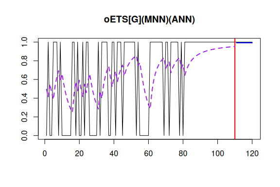

```r
plot(omgModel, 7)
```

Calling `om(..., occurrence="general")` is a shortcut that delegates to `omg()` with the same model specification on both sides.

## auto.om(): automatic occurrence type selection

`auto.om()` fits `om()` (or `omg()`) for each candidate occurrence type and returns the model with the lowest information criterion. By default all five types are tested:

```r
autoOmModel <- auto.om(y, model="MNN", h=10, holdout=TRUE)
autoOmModel
```

```
## Occurrence model
## Time elapsed: 0.29 seconds
## Model estimated using auto.om() function: oETS(MNN)[D]
## With backcasting initialisation
## Distribution assumed in the model: Cumulative Logistic
## Loss function type: likelihood; Loss function value: 59.2279
## Persistence vector g:
##  alpha
## 0.1137
##
## Sample size: 110
## Number of estimated parameters: 2
## Number of degrees of freedom: 108
## Information criteria:
##      AIC     AICc      BIC     BICc
## 122.4558 122.5680 127.8568 128.1204
##
## Forecast errors:
## Asymmetry: 100%; sMSE: 0.008%; rRMSE: Inf; sPIS: -49.013%; sCE: 8.912%
```

Passing `orders=list(ar=2, i=1, ma=2, select=TRUE)` activates automatic ARIMA order selection for each candidate occurrence type, returning the best overall combination of occurrence link and ARIMA structure:

```r
autoOmARIMA <- auto.om(y, model="MNN",
                       orders=list(ar=2, i=1, ma=2, select=TRUE),
                       h=10, holdout=TRUE)
autoOmARIMA
```

```
## Occurrence model
## Time elapsed: 0.23 seconds
## Model estimated using auto.om() function: oETS(MNN)[D]
## With backcasting initialisation
## Distribution assumed in the model: Cumulative Logistic
## Loss function type: likelihood; Loss function value: 59.2279
## Persistence vector g:
##  alpha
## 0.1137
##
## Sample size: 110
## Number of estimated parameters: 2
## Number of degrees of freedom: 108
## Information criteria:
##      AIC     AICc      BIC     BICc
## 122.4558 122.5680 127.8568 128.1204
##
## Forecast errors:
## Asymmetry: 100%; sMSE: 0.008%; rRMSE: Inf; sPIS: -49.013%; sCE: 8.912%
```

A subset of occurrence types can be tested by supplying an explicit vector:

```r
autoOmSubset <- auto.om(y, model="MNN",
                        occurrence=c("fixed", "odds-ratio", "inverse-odds-ratio"),
                        h=10, holdout=TRUE)
autoOmSubset
```

```
## Occurrence model
## Time elapsed: 0.16 seconds
## Model estimated using auto.om() function: oETS(MNN)[O]
## With backcasting initialisation
## Distribution assumed in the model: Cumulative Logistic
## Loss function type: likelihood; Loss function value: 61.5463
## Persistence vector g:
##  alpha
## 0.5605
##
## Sample size: 110
## Number of estimated parameters: 2
## Number of degrees of freedom: 108
## Information criteria:
##      AIC     AICc      BIC     BICc
## 127.0925 127.2047 132.4935 132.7570
##
## Forecast errors:
## Asymmetry: 100%; sMSE: 0.072%; rRMSE: Inf; sPIS: -147.893%; sCE: 26.89%
```

## See also

The oETS model family and its mathematical foundations are documented in detail in the oes vignette. The `oes()` function provides these same oETS models with a simpler, ETS-only interface. For the full intermittent demand model that combines occurrence and demand sizes, use `adam()` with the estimated occurrence model passed to the `occurrence` argument.